# R Project

Alki Leka

```
                                                        Permbajtja
```

-`Job Title` —————– Ndryshore cilesore

-`Average Salary $` ———- Ndryshore sasiore

-`Rating` ——————– Ndryshore cilesore

-`Company Name` ————– Ndryshore cilesore

-`Location` —————— Ndryshore cilesore

-`Headquarters` ————– Ndryshore cilesore

-`Number of employes` ——– Ndryshore sasiore

-`Founded` ——————- Ndryshore cilesore

-`Industry` —————— Ndryshore cilesore

-`Sector` ——————– Ndryshore cilesore

-`Average Revenue $` ——— Ndryshore sasiore

Kjo databazë është marrë ne shqyrtim pasi fusha në të cilën ne po kryejmë studimet ka një lidhje të fortë me të dhënat dhe databazat, sigurisht duke marrë në konsidratë dhe profilin e specializimit që do të kryhet në një moment të mëvonshëm. Ky projekt na mundëson të kuptojmë dhe të krijojmë një ide mbi kërkesat dhe veprimtaritë të cilat mund të kërkohen në lidhje me profilet e punës dhe specializimet të cilat mund të ndiqen në fushën e studimeve statistikore.

Databaza e përzgjedhur, përvec faktorit studiues, është përzgjedhur dhe për faktorin informues. Duke qënë se kjo databaze ka marrë në studim dhe ka paraqitur një studim të përmbledhur rreth pozicionit si Data Analyst në kompani, industri dhe sektorë të ndryshëm, si dhe është një databazë e cila është paraqitur brenda 5 viteve të fundit, kjo na tregon se kjo databazë është koherente. Duke marrë parasysh faktet e sipërpërmendura ne mundemi që, falë kësaj databaze si dhe studimit të saj në projekt të përcaktojmë:

-Pagesat minimale dhe maksimale koherente të profilit Data Analyst. -Lokacionet kryesore të ushtrimit të ketij profili. -Kompanitë dhe pagesat respektive për cdo pozicion të ofruar nga cdo kompani. -Sektorët me kërkesat më të larta sipas profilit të punës.

```
                                      Le të fillojmë me studimin e databazës
```

Për të kryer studimet e nevojshme si fillim ne duhet të instalojmë dhe të therrasim disa paketa funksionesh të ndryshme të cilët na mundësojnë përmbledhjet dhe vizualizimet e të dhënave falë grafikëve dhe/ose tabelave të ndryshme.

Pas instalimit të paketave të nevojshme, ne përcaktojmë dhe thërrasim databazën, falë një funksioni, në mënyrë që të vijojmë me studimin e saj.

```r
#install.packages("dplyr")
library(dplyr)               #Kjo paketë mundeson manipulimin e të dhënave dhe paraqitjen e tyre në mënyrë tabelore.

#install.packages("tidyr")
library(tidyr)               #Kjo pakete mundeson manipulimin e te dhenave.

#install.packages("ggplot2")
library(ggplot2)             #Kjo pakete mundeson krijimin e grafikeve bazuar ne te dhenat e paraqitura.

#install.packages("knitr")
library(knitr)               #Kjo pakete mundeson manipulimin e te dhenave ne menyre tabelore.

#install.packages("ggpubr")
library(ggpubr)              #Kjo pakete mundeson nje pordorim sa me te gjere dhe te mire te paketes ggplot2.

#install.packages("readr")
library(readr)               #Kjo pakete mundeson leximin e te dhenave te ndryshme te importuara nga dokumente te jashtem.

#install.packages("readxl")
library(readxl)              #Kjo pakete mundeson leximin e te dhenave te paraqitura nga Excel-i.

#install.packages("readxl")
library(esquisse)           #Kjo pakete mundeson interaktivitetin ndermjet pordoruesve dhe grafikeve te ndertuar.


data.analyst <- read_excel("C:/Users/User/OneDrive/Desktopi/R Project/Data.Analyst.xlsx")
head(data.analyst)
```

| Job Title | Average Salary $ | Rating | Company Name | Location | Headquarters | Number of employes | Founded | Industry | Sector | Average Revenue $ |
| --- | --- | --- | --- | --- | --- | --- | --- | --- | --- | --- |
| Data Analyst, Center on Immigration and Justice (CIJ) | 51500 | 3.2 | Vera Institute of Justice | New York, NY | New York, NY | 500 | 1961 | Social Assistance | Non-Profit | 3.0e+08 |
| Quality Data Analyst | 51500 | 3.8 | Visiting Nurse Service of New York | New York, NY | New York, NY | 10000 | 1893 | Health Care Services & Hospitals | Health Care | 3.5e+09 |
| Data Analyst | 51500 | 4.1 | Celerity | New York, NY | McLean, VA | 500 | 2002 | IT Services | Information Technology | 7.5e+07 |
| Reporting Data Analyst | 51500 | 3.9 | FanDuel\r\n | New York, NY | New York, NY | 1000 | 2009 | Sports & Recreation | Arts, Entertainment & Recreation | 3.0e+08 |
| Data Science Analyst | 51500 | 3.7 | GNY Insurance Companies\r\n | New York, NY | New York, NY | 500 | 1914 | Insurance Carriers | Insurance | 3.0e+08 |
| Data Analyst | 51500 | 4.0 | DMGT\r\n | New York, NY | London, United Kingdom | 10000 | 1896 | Venture Capital & Private Equity | Finance | 1.5e+09 |

```r
NA
```

```
                                                      Njohja me ndryshoret
```

Pas instalimit të paketave shohim disa nga karakteristikat kryesore si dhe një paraqitje të shkurtër të të dhënave. Kjo mund të kryhet duke përdorur funksionin str.

```r
str(data.analyst)
```

```
tibble [1,193 × 11] (S3: tbl_df/tbl/data.frame)
 $ Job Title         : chr [1:1193] "Data Analyst, Center on Immigration and Justice (CIJ)" "Quality Data Analyst" "Data Analyst" "Reporting Data Analyst" ...
 $ Average Salary $  : num [1:1193] 51500 51500 51500 51500 51500 51500 51500 51500 51500 51500 ...
 $ Rating            : num [1:1193] 3.2 3.8 4.1 3.9 3.7 4 4 3.7 3 3.4 ...
 $ Company Name      : chr [1:1193] "Vera Institute of Justice" "Visiting Nurse Service of New York" "Celerity" "FanDuel\r\n" ...
 $ Location          : chr [1:1193] "New York, NY" "New York, NY" "New York, NY" "New York, NY" ...
 $ Headquarters      : chr [1:1193] "New York, NY" "New York, NY" "McLean, VA" "New York, NY" ...
 $ Number of employes: num [1:1193] 500 10000 500 1000 500 10000 10000 10000 500 5000 ...
 $ Founded           : num [1:1193] 1961 1893 2002 2009 1914 ...
 $ Industry          : chr [1:1193] "Social Assistance" "Health Care Services & Hospitals" "IT Services" "Sports & Recreation" ...
 $ Sector            : chr [1:1193] "Non-Profit" "Health Care" "Information Technology" "Arts, Entertainment & Recreation" ...
 $ Average Revenue $ : num [1:1193] 3.0e+08 3.5e+09 7.5e+07 3.0e+08 3.0e+08 1.5e+09 7.5e+09 3.5e+09 3.0e+08 3.0e+06 ...
```

Shohim që funksioni str ka shfaqur të gjithë ndryshoret e databazës si dhe ka paraqitur disa të dhëna përkundrejt cdo ndryshorje. Këto të dhëna përfshijnë: përcaktimin e vleres(nëse ajo është vlerë numerike apo tekst/karakter), shtrirjen e të dhënave përkundrejt secilës ndryshore në databazë si dhe ka shfaqur disa nga vlerat e ndodhura në disa nga rreshtat e parë të databazës.

```
                                                     Studimi i ndryshoreve
```

Duke qënë se ne arritëm të përcaktojmë disa nga të dhënat e databazës si dhe arritëm te shohim disa vlera dhe karaktere konkretë të databazës, në vazhdim ne do të analizojmë të gjithë databazën në bazë të ndryshoreve të sipërpërmendura.

-Si fillim le të marrim në shqyrtim të dhënat e paraqitura në lidhje me pagat mesatare të punonjësve.

```r
salary=data.analyst$`Average Salary $`
summary(salary)
```

```
   Min. 1st Qu.  Median    Mean 3rd Qu.    Max.
  33500   56000   68000   71418   80500  150000
```

#Duke përdorur funksionin e mësipërm (summary()), ne arrijmë të shohim që paga mesatare e një punonjësi të profilit Data Analyst varion rreth vlerës 71’418 $, ku vlera minimale është 33’500 $ dhe ajo maksimale është 150’000 $.

-Marrim në vrojtim të dhënat mbi vlerësimet e kompanive.

```r
Rating=data.analyst$Rating
summary(Rating)
```

```
   Min. 1st Qu.  Median    Mean 3rd Qu.    Max.
  1.800   3.400   3.700   3.739   4.000   5.000
```

Nga vlerësimi i bërë shohim që vlerësimi mesatar i kompanive është 3.739/5. Vlerësimi minimal është 1.8 ndërsa ai maksimal është 5. Nga vlerësimi i bëre falë këtyre të dhënave ne arrijmë në konkluzionin që kompanite qe ofrojne kete profil pune jane kompani me vleresime kryesisht pozitive.

-Marrim ne studim numrin e punonjesve te kompanive (vlen te permendet fakti qe numri i punonjesve eshte kufizuar nga 0-10000, ky kufizim vjen per faktin se disa kompani nuk kane publikuar nje numer ekzakt te punonjesve)

```r
employes=data.analyst$`Number of employes`
summary(employes)
```

```
   Min. 1st Qu.  Median    Mean 3rd Qu.    Max.
     50     500    5000    4599   10000   10000
```

Kjo analize na tregon se numri mesatar i funonjesve te nje kompanie eshte 4599 punonjes. Nga kjo analize ne shohim qe numri minimal i punonjesve te nje kompanie eshte 50 punonjes nderkohe qe ai maksimali eshte 10000 punonjes.

-Marrim ne analize fitimet mesatare vjetore te kompanive

```r
revenue=data.analyst$`Average Revenue $`
summary(revenue)
```

```
     Min.   1st Qu.    Median      Mean   3rd Qu.      Max.
3.000e+06 7.500e+07 3.000e+08 1.654e+10 3.500e+09 1.000e+11
```

```
                                             Studimi i disa karakteristikave
```

Ne studimin ne vijime ne do te mund te studiojme cdo ndryshore te databazes, qofte ajo ndryshore cilesore apo sasiore.

-Se pari le te analizojme disa te dhena cilesore

```r
job_title=data.analyst$`Job Title`

industry=data.analyst$Industry

sector=data.analyst$Sector

length(which(job_title=='Data Analyst'))
```

```
[1] 199
```

```r
length(which(industry=='IT Services'))
```

```
[1] 247
```

```r
length(which(sector=='Information Technology'))
```

```
[1] 390
```

Nga te dhenat e mesiperme ne mund te percaktojme numrin specifik te disa nga profilet e punes te cilat ofrohen nga kompani te ndryshme:

-Data Analyst - rreth 199 punonjes ofrojne sherbimet e tyre ne kete profil

-IT Services - rreth 247 punonjes ofrojne sherbimet e tyre ne kete profil

-Le te analizojme ne menyre tabelore vitet e themelimit.

```r
Founded=data.analyst$Founded
table(Founded)
```

```
Founded
1682 1698 1784 1785 1799 1807 1812 1817 1818 1828 1830 1832 1837 1841 1845 1850 1852 1853 1855 1856 1857 1859 1862 1864 1865 1867
   1    1    9    1   10    1    7    2    1    1    1    1    1    4    2    1    2    1    3    1    1    1    2    8    1    2
1868 1869 1870 1872 1874 1875 1876 1880 1882 1884 1885 1886 1888 1889 1890 1891 1892 1893 1895 1896 1897 1898 1901 1902 1904 1905
   2    4    3    1    2    1    1    1    2    2    1    2    3    3    3    1    5    1    1    2    1    1    2    5    4    1
1906 1907 1909 1911 1912 1913 1914 1916 1917 1918 1919 1922 1923 1924 1926 1928 1930 1931 1932 1933 1934 1935 1936 1937 1938 1939
   3    2    1    2    1    1    5    3    1    1    1    1    8    1    1    1    3    1    2    2    1    7    2    3    4    6
1944 1945 1946 1947 1948 1949 1951 1952 1953 1954 1955 1956 1957 1958 1959 1960 1961 1962 1963 1964 1965 1966 1967 1968 1969 1970
   1    7   13    5   15    5    5    2    2    1    2    3    6    1    2    2    5    9    3    5    1   29   17    6    4   10
1971 1972 1973 1974 1975 1976 1977 1978 1979 1980 1981 1982 1983 1984 1985 1986 1987 1988 1989 1990 1991 1992 1993 1994 1995 1996
   3    3    5    1    9   15    7    4    4   12    6    8   16   18   13    4    5    8   12   20   14   16    8   23   30   44
1997 1998 1999 2000 2001 2002 2003 2004 2005 2006 2007 2008 2009 2010 2011 2012 2013 2014 2015 2016 2017 2018 2019
  36   44   44   50   28   49   12   32   22   22   19   76   13   19   23   13   12   10    3    3    3    4    2
```

-Le te bejme nje permbledhje te te gjitha ndryshoreve te databazes.

```r
summary(data.analyst)
```

```
  Job Title         Average Salary $     Rating      Company Name         Location         Headquarters       Number of employes
 Length:1193        Min.   : 33500   Min.   :1.800   Length:1193        Length:1193        Length:1193        Min.   :   50
 Class :character   1st Qu.: 56000   1st Qu.:3.400   Class :character   Class :character   Class :character   1st Qu.:  500
 Mode  :character   Median : 68000   Median :3.700   Mode  :character   Mode  :character   Mode  :character   Median : 5000
                    Mean   : 71418   Mean   :3.739                                                            Mean   : 4599
                    3rd Qu.: 80500   3rd Qu.:4.000                                                            3rd Qu.:10000
                    Max.   :150000   Max.   :5.000                                                            Max.   :10000
    Founded       Industry            Sector          Average Revenue $
 Min.   :1682   Length:1193        Length:1193        Min.   :3.000e+06
 1st Qu.:1966   Class :character   Class :character   1st Qu.:7.500e+07
 Median :1995   Mode  :character   Mode  :character   Median :3.000e+08
 Mean   :1974                                         Mean   :1.654e+10
 3rd Qu.:2002                                         3rd Qu.:3.500e+09
 Max.   :2019                                         Max.   :1.000e+11
```

Nga ky funksion permbledhes i databazes ne shohim qe paraqiten te gjitha ndryshoret e databazes dhe disa nga te dhenat specifike studiuese per secilen ndryshore.

```
                                           Ndertimi i Grafikerve te Ndryshorev
```

Ne vazhdim ne, perkundrejt paraqitjeve tabelore, do te kryejme dhe disa paraqitje vizuale te te dhenave fale grafikeve.

-Le te ndertojme grafikun e vleresimeve ne lidhje me velresimet dhe numrin e kompanive te cilat i perkasin atyre vleresimeve.

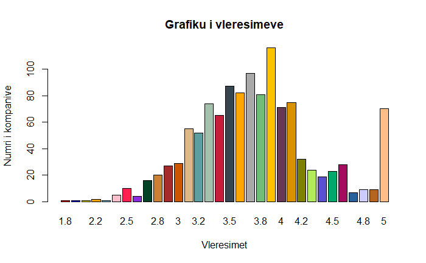

```r
barplot(table(Rating), col = c("red","blue","yellow","orange","skyblue","pink","#ff2052","#8a2be2","#004225","#cd7f32","#a52a2a","#cc5500","#deb887","#5f9ea0","#a3c1ad","#c41e3a","#36454f","#ffa700","#a9a9a9","#71bc78","#fcc200","#663854","#da9100","#808000","#b2ec5d","#5a4fcf","#00a86b","#a50b5e","#26619c","#ccccff","#b5651d","#ffbd88"), xlab = "Vleresimet", ylab = "Numri i kompanive", main = "Grafiku i vleresimeve")
```

Nga kjo paraqitje vizuale ne mund te shohim qe vleresimi 3.9 eshte arritur ne shume kompani.

-Le te ndertojme nje grafik i cili paraqet lidhjen ndermjet pages mesatare dhe numrit te punonjesve.

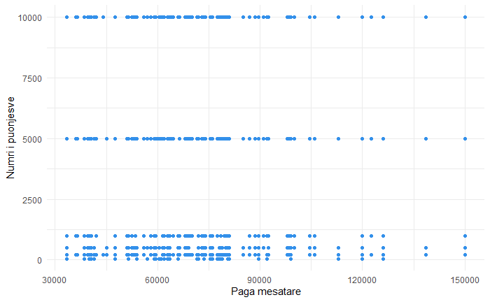

```r
library(esquisse)
#esquisser(data.analyst, viewer = "browser")

library(ggplot2)

ggplot(data.analyst) +
  aes(x = `Average Salary $`, y = `Number of employes`) +
  geom_point(shape = "circle", size = 1.5, colour = "#3390EA") +
  labs(x = "Paga mesatare", y = "Numri i puonjesve") +
  theme_minimal()
```

-Le te ndertojme nje tabele statistikore sipas disa intervaleve te percaktuara nga ne.

```r
tab=table(cut(data.analyst$Rating, breaks = c(1,2,2.5,3,3.2,3.5,4,4.2,4.5,4.7,5)))
V=c(tab)
```

Pas ndertimit te tabeles statistikore le te ndertojme nje tabele ne te cilen te paraqesim efektivat, efektivat e grumbulluar, frekuencat, frekuencat e grumbulluara.

```r
df=data.frame(Efektivat=V, Efektivat_e_grumbulluar=cumsum(V), Frekuenca=V/sum(V), Frekuenca_e_grumbulluar=cumsum(V/sum(V)))
knitr::kable(df, caption = "Tabela statistikore mbi vleresimet")
```

Tabela statistikore mbi vleresimet

|  | Efektivat | Efektivat_e_grumbulluar | Frekuenca | Frekuenca_e_grumbulluar |
| --- | --- | --- | --- | --- |
| (1,2] | 2 | 2 | 0.0016764 | 0.0016764 |
| (2,2.5] | 19 | 21 | 0.0159262 | 0.0176027 |
| (2.5,3] | 96 | 117 | 0.0804694 | 0.0980721 |
| (3,3.2] | 107 | 224 | 0.0896899 | 0.1877619 |
| (3.2,3.5] | 226 | 450 | 0.1894384 | 0.3772003 |
| (3.5,4] | 447 | 897 | 0.3746857 | 0.7518860 |
| (4,4.2] | 107 | 1004 | 0.0896899 | 0.8415759 |
| (4.2,4.5] | 66 | 1070 | 0.0553227 | 0.8968986 |
| (4.5,4.7] | 35 | 1105 | 0.0293378 | 0.9262364 |
| (4.7,5] | 88 | 1193 | 0.0737636 | 1.0000000 |

```r
NA
```

Nga kjo tabele ne shohim qe efektivat dhe frekuenca me e larte eshte ndermjet vleresimeve 3,5 dhe 4, gje kjo e cila eshte paraqitur ne menyre me specifike dhe vizuale ne grafikun me kolona me siper.